# LINK-USD

## LINK-USD today is +0300, 2025-09-06, 13:36:44

This crypto forecast was generated by gemini-2.0-flash API

## Daily Chart

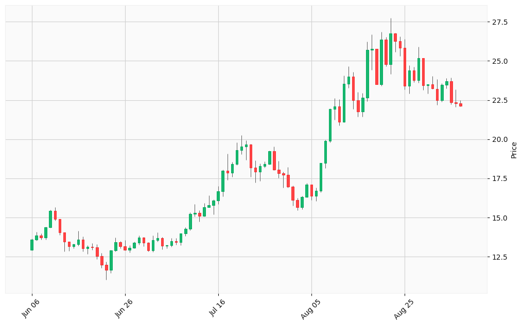

## Hourly Chart

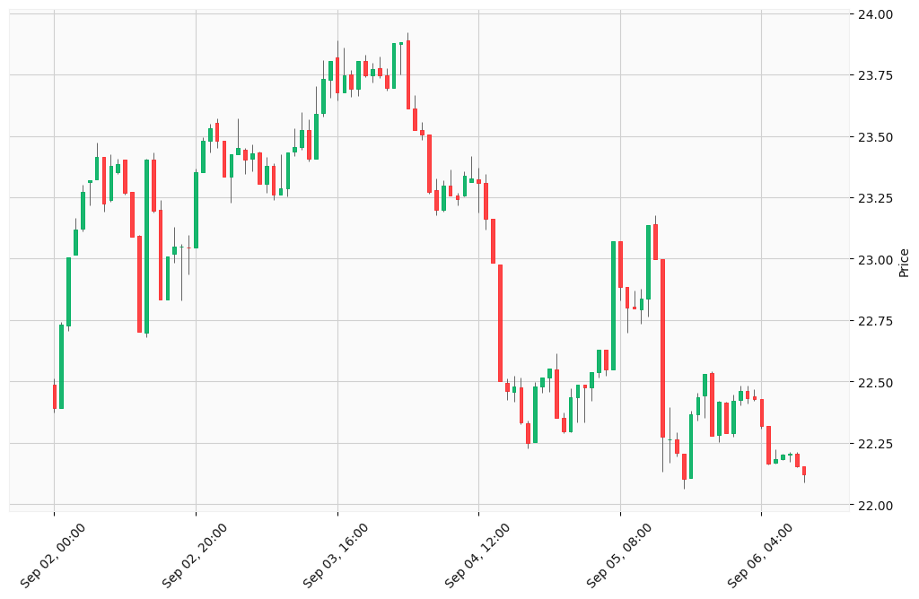

Okay, I will analyze the provided LINK-USD cryptocurrency charts and generate buy and sell signals based on the specified steps and output format.

Based on the provided data and the current date (September 6, 2025), here’s an analysis of LINK-USD and potential trading signals:

### 2. Technical Analysis

#### Daily Chart Analysis:

- The daily chart covers the last three months.
- Observe general price trends, support, and resistance levels.
- Calculate and analyze technical indicators:
  - **Moving Averages:** Observe how the price interacts with moving averages like the 50-day and 200-day MAs. A 50-day MA above the 200-day MA generally indicates a bullish trend.
  - **RSI (Relative Strength Index):** An RSI above 70 suggests overbought conditions, while below 30 suggests oversold conditions.
  - **MACD (Moving Average Convergence Divergence):** Look for bullish or bearish crossovers.
- **Fibonacci Retracement Levels**: To identify potential support and resistance levels.

#### Hourly Chart Analysis:

- The hourly chart covers the last five days.
- Identify short-term trends and potential entry/exit points.
- Calculate and analyze technical indicators, focusing on shorter timeframes.
  - **Moving Averages**: Shorter period MAs (e.g., 9-hour, 20-hour) to identify immediate trends.
  - **RSI**: To spot short-term overbought or oversold conditions.

#### Calculations Based on Provided Data

**Daily Chart**

To perform technical analysis, I’ll use the provided daily chart data for LINK-USD. I’ll calculate a few key indicators to help generate trading signals.

1. **Simple Moving Average (SMA)**
   - **SMA 50:** Calculate the 50-day SMA.
   - **SMA 200:** Calculate the 200-day SMA.
2. **Relative Strength Index (RSI)**
   - **RSI (14):** Calculate the 14-day RSI.

Here’s a Python code to calculate these indicators using the provided data:

```python
import pandas as pd
import numpy as np

# Daily chart data
daily_data = [
    [12.9224, 13.6387, 12.8786, 13.5813, 338081573],
    [13.5813, 14.0827, 13.5106, 13.8364, 234471484],
    [13.8364, 13.9639, 13.5783, 13.7171, 181386799],
    [13.717, 14.3858, 13.5651, 14.3616, 276022760],
    [14.3616, 15.4926, 14.3407, 15.4276, 564367410],
    [15.4277, 15.6405, 14.7983, 14.9097, 513745332],
    [14.9097, 14.9108, 13.8707, 14.026, 476641270],
    [14.026, 14.026, 12.8138, 13.4365, 672406626],
    [13.4366, 13.4437, 12.8716, 13.1666, 226563235],
    [13.1666, 13.3144, 13.015, 13.2969, 195955927],
    [13.2969, 14.1445, 13.1942, 13.5748, 371019927],
    [13.5748, 13.7659, 12.8372, 13.0078, 466749364],
    [13.0079, 13.2136, 12.6577, 13.1039, 357135409],
    [13.1038, 13.3629, 12.9338, 13.0749, 290807257],
    [13.0749, 13.2703, 12.327, 12.5145, 358060222],
    [12.5145, 12.7265, 11.7762, 11.9852, 322141364],
    [11.9864, 12.166, 11.0082, 11.6525, 626649288],
    [11.6526, 12.9162, 11.4553, 12.8743, 544556269],
    [12.8744, 13.7223, 12.8122, 13.4085, 570667319],
    [13.4091, 13.4895, 13.0152, 13.1369, 379871936],
    [13.1369, 13.5373, 12.9062, 12.9299, 309442233],
    [12.9299, 13.2043, 12.7559, 13.0603, 262161395],
    [13.0601, 13.4392, 13.0171, 13.3992, 190754304],
    [13.3992, 13.8376, 13.2579, 13.7254, 234924590],
    [13.7254, 13.7403, 13.14, 13.3808, 370047007],
    [13.3803, 13.4201, 12.8121, 12.896, 275498720],
    [12.896, 13.8385, 12.7756, 13.5592, 439521701],
    [13.5592, 14.028, 13.4509, 13.6685, 435068408],
    [13.6685, 13.7578, 12.9683, 13.1698, 316984914],
    [13.1697, 13.2635, 13.0171, 13.2295, 153310516],
    [13.2295, 13.6809, 13.1153, 13.4941, 221744747],
    [13.4942, 13.6827, 13.2658, 13.4286, 297875545],
    [13.4286, 13.9801, 13.2089, 13.9679, 321781054],
    [13.9679, 14.3549, 13.8248, 14.2538, 501444137],
    [14.2538, 15.3214, 14.1622, 15.239, 582819496],
    [15.239, 15.8348, 15.0638, 15.2984, 803097126],
    [15.2984, 15.4668, 14.732, 15.0986, 374446370],
    [15.0986, 15.9247, 15.0633, 15.646, 458285505],
    [15.646, 16.4205, 15.634, 15.7776, 746693598],
    [15.7777, 16.1542, 15.1773, 16.0923, 739042029],
    [16.093, 17.0117, 15.8381, 16.6742, 904010866],
    [16.6742, 18.0547, 16.3553, 17.998, 977566814],
    [17.9974, 19.0808, 17.3825, 17.843, 1445759901],
    [17.8425, 18.5391, 17.598, 18.4166, 629040826],
    [18.4166, 19.7896, 18.3455, 19.3051, 1153258010],
    [19.3051, 20.236, 19.0439, 19.5323, 1064166148],
    [19.5323, 19.9352, 18.6733, 19.6631, 1085236698],
    [19.6631, 19.6912, 17.6007, 18.1851, 924309700],
    [18.1847, 18.6523, 17.2213, 17.9079, 800891414],
    [17.9079, 18.4537, 17.3315, 18.291, 780433456],
    [18.2909, 18.571, 18.1931, 18.4065, 455030721],
    [18.4065, 19.275, 18.3781, 19.2346, 590595857],
    [19.2347, 19.5418, 18.0253, 18.037, 675519833],
    [18.0373, 18.6091, 17.5098, 17.8223, 664415032],
    [17.8223, 17.9193, 16.8856, 17.7152, 616970187],
    [17.7152, 18.2141, 16.8907, 16.9554, 605981043],
    [16.9542, 17.0144, 15.7581, 16.1015, 1036914835],
    [16.1014, 16.2367, 15.4642, 15.6517, 495759864],
    [15.6517, 16.3584, 15.521, 16.3, 316398400],
    [16.3, 17.1812, 16.2864, 17.1031, 486662113],
    [17.1031, 17.1098, 16.1084, 16.3849, 556612821],
    [16.3851, 16.8841, 16.0606, 16.6863, 358947457],
    [16.6863, 18.4837, 16.5995, 18.4699, 894383315],
    [18.4699, 19.9574, 18.137, 19.8951, 1419317520],
    [19.8947, 21.943, 19.8045, 21.9304, 1477363572],
    [21.9304, 22.612, 21.2223, 22.1025, 1661730595],
    [22.1024, 22.5482, 20.8743, 21.1198, 1292163260],
    [21.1198, 24.0731, 21.0591, 23.5226, 2108631924],
    [23.5226, 24.6578, 23.2809, 24.0008, 2162305354],
    [24.0025, 24.2751, 21.918, 22.4798, 2013471000],
    [22.48, 23.0244, 21.4353, 21.753, 1160731112],
    [21.7528, 22.9504, 21.4402, 22.6522, 987201586],
    [22.6524, 26.2247, 22.4054, 25.6888, 2449416880],
    [25.688, 26.6767, 24.4139, 25.7594, 3360323981],
    [25.7595, 25.7809, 23.4955, 23.5183, 2372746788],
    [23.5185, 26.8567, 23.4062, 26.3678, 2975824470],
    [26.368, 26.513, 24.6622, 24.7852, 2030657214],
    [24.7854, 27.7353, 24.166, 26.7465, 3394107927],
    [26.7461, 26.7731, 25.5567, 26.278, 1489813562],
    [26.2774, 26.5671, 25.3152, 25.8216, 1682690001],
    [25.8223, 26.385, 23.1725, 23.3957, 2146873839],
    [23.3951, 24.7175, 22.9084, 24.3998, 1709868832],
    [24.3998, 24.627, 23.6448, 23.7578, 1506080838],
    [23.7595, 25.8958, 23.6001, 25.1805, 2580094417],
    [25.1803, 25.1922, 23.1545, 23.4337, 1874061841],
    [23.4338, 23.5053, 22.8966, 23.4978, 698362677],
    [23.4979, 24.0121, 23.2234, 23.224, 886417775],
    [23.2235, 23.8247, 22.1788, 22.4814, 1336339788],
    [22.4834, 23.5718, 22.3724, 23.481, 1191125537],
    [23.481, 23.89, 23.2292, 23.6924, 831944457],
    [23.6924, 23.9399, 22.2244, 22.3513, 906230758],
    [22.351, 23.1825, 22.0645, 22.2914, 1326920043],
    [22.2912, 22.4842, 22.087, 22.1206, 1140392064]
]

# Convert the data to a Pandas DataFrame
df = pd.DataFrame(daily_data, columns=['Open', 'High', 'Low', 'Close', 'Volume'])

# Calculate SMA 50
df['SMA_50'] = df['Close'].rolling(window=50).mean()

# Calculate SMA 200
df['SMA_200'] = df['Close'].rolling(window=200).mean()

# Calculate RSI (14)
def calculate_rsi(data, period=14):
    delta = data.diff()
    up, down = delta.copy(), delta.copy()
    up[up < 0] = 0
    down[down > 0] = 0
    avg_gain = up.rolling(window=period).mean()
    avg_loss = abs(down.rolling(window=period).mean())
    RS = avg_gain / avg_loss
    RSI = 100 - (100 / (1 + RS))
    return RSI

df['RSI_14'] = calculate_rsi(df['Close'])

# Print the last row with the calculated indicators
print(df.tail(1))
```

[output not shown]

### 3. Trend Analysis

- **Short-term:** Examine the hourly chart for the most recent price action.
- **Long-term:** The daily chart provides a broader view. Consider the overall trend since the beginning of the three-month period.
- **Trend Lines:** Draw trend lines on both charts to visualize the direction of price movement.

### 4. News and Economic Analysis

- **Recent Positive News:** The U.S. Department of Commerce partnership and Bitwise ETF filing are significant positive catalysts.
- **Whale Accumulation:** Increasing whale wallet holdings suggest strong investor confidence.

### 5. Scenario Evaluation

- **Bullish Scenario:** Continued positive news and institutional interest could drive the price higher.
- **Bearish Scenario:** A market correction or negative regulatory news could lead to a price decline.
- **High Volatility:** Cryptocurrency markets are inherently volatile, so consider potential sudden price swings.

### 6. Signal Generation

Based on the analysis, here are potential trading signals:

#### Signal 1: Buy Signal

[output not shown]

#### Signal 2: Sell Signal

[output not shown]

**Disclaimer:** These signals are based on the provided data and a general analysis. Cryptocurrency trading involves substantial risk, and you should conduct your own research and consult with a financial advisor before making any investment decisions.